# The Promise and Pitfalls of Spatial Epidemiology in Firearm Violence Research

2024-12-09

# 1. Setup

## 1.1. Install packages

First, please install any of the following packages required for this tutorial if you do not already have them installed.

```r
# Spatial packages
install.packages("sf")
install.packages("spdep")
# The INLA package is not listed on the CRAN repository and must be manually installed using this code:
install.packages("INLA",repos=c(getOption("repos"),INLA="https://inla.r-inla-download.org/R/stable"), dep=TRUE)

# Data management
install.packages("tidyverse")
install.packages("janitor")
install.packages("viridis")
install.packages("lubridate")
```

## 1.2. Load packages

Load the packages that we will use in the tutorial. These packages give us functions to help with the following:

- `sf`: working with and mapping spatial data
- `spdep`: spatial data analysis
- `INLA`: Bayesian inference
- `tidyverse`: data wrangling
- `janitor`: data cleaning
- `viridis`: color palette to improve readability for folks with color vision deficiency
- `lubridate`: date manipulation

```r
# Spatial packages
library(sf)
library(spdep)
library(INLA)

# Data management
library(tidyverse)
library(janitor)
library(viridis)
library(lubridate)
```

## 1.3. Set Root Directory

This code is needed so that the relative paths used in the data importing later in this code can be the same when running the code individually and knitting this RMarkdown file.

```r
knitr::opts_knit$set(root.dir = ".")
```

# 2. Import & prepare data

Before starting our analysis, we need to bring in and prepare our data. In this analysis we will be looking at the association between the Heat Vulnerability Index (HVI) and shootings in Brooklyn, NY using publicly available data. The HVI is available at the ZIP code level, meaning that our units of analysis will be ZIP codes in Brooklyn. We need to prepare our data so that we have the number of shooting incidents for each ZIP code and its HVI score. The HVI is available for NYC ZIP codes for the year 2017, so the rest of the data will be filtered to maintain the same study period.

## 2.1. Import data

We will be importing both tabular and spatial data. The tabular data contain coordinates (latitude and longitude) for points that we can use to create spatial data, or contain a linking variable that will be used to join them to spatial data.

We will use the `sf::st_read()` function to import spatial data files into R. You can see that the file imported is a “simple feature” (sf), which is a spatial data format in R.

The shooting incident data and HVI data are saved as CSV files. We will use the `readr::read_csv()` function to import these tabular data.

As we import data, we will also clean and prepare them for our analysis.

```r
# Import NYC borough boundaries spatial data
boroughs <- st_read("Data/Borough Boundaries/geo_export_c9e24719-8fdb-47dc-bbec-784e93bac695.shp")
# Import national ZIP codes spatial data
zipcodes <- st_read("Data/tl_2020_us_zcta520/tl_2020_us_zcta520.shp")
```

```r
# Import shooting incidents tabular data
shootings_2017 <- read_csv("Data/NYPD_Shooting_Incident_Data__Historic__20241002.csv") %>%
  clean_names(.) %>% # Clean variable names for easier manipulation in R
  mutate(year=year(mdy(occur_date))) %>% # Create a year variable to filter data for study period
  filter(year==2017) # Limit data to study period
# Import HVI tabular data
hvi <- read_csv("Data/Heat_Vulnerability_Index_Rankings_20241002.csv") %>%
  clean_names(.) %>% # Clean variable names for easier manipulation
  rename(zcta=zip_code_tabulation_area_zcta_2020,
         hvi=heat_vulnerability_index_hvi) %>% # Rename variables for easier manipulation
  mutate(zcta=as.character(zcta)) # Convert `zcta` variable to character class - needed for joining to spatial data
```

## 2.2. Prepare data

### 2.2.1. Brooklyn ZIP codes

ZIP code polygons are available from the US Census Bureau at the national level. We want to select only the ZIP codes that are located in Brooklyn. We will do this by taking the centroid (geographic center of each ZIP code polygon) and comparing it the polygon of Brooklyn. Any centroid that is within the Brooklyn polygon will be kept for our analysis.

#### … Transform CRS

Before we calculate the centroids, an important step is to make sure that the spatial data we have are in the same Coordinate Reference System (CRS). These are related to map projections - a way to transform the earth from its spherical (3D) shape to a planar (2D) shape. A CRS defines how the 2D, projected map as part of spatial data relates to real places on earth. Since there are many different CRS’s, we need to make sure that when we compare spatial data that they are projected in the same CRS. Otherwise, there will be misalignment of our spatial data. We can check a simple feature’s CRS in R by using the `sf::st_crs()` function.

```r
# Filter the NYC boroughs spatial data to get the polygon for Brooklyn
brooklyn <- boroughs %>%
  filter(boro_name == "Brooklyn")

# Compare CRS
# Check the CRS for Brooklyn
st_crs(brooklyn)
```

```
## Coordinate Reference System:
##   User input: WGS84(DD)
##   wkt:
## GEOGCRS["WGS84(DD)",
##     DATUM["WGS84",
##         ELLIPSOID["WGS84",6378137,298.257223563,
##             LENGTHUNIT["metre",1,
##                 ID["EPSG",9001]]]],
##     PRIMEM["Greenwich",0,
##         ANGLEUNIT["degree",0.0174532925199433]],
##     CS[ellipsoidal,2],
##         AXIS["longitude",east,
##             ORDER[1],
##             ANGLEUNIT["degree",0.0174532925199433]],
##         AXIS["latitude",north,
##             ORDER[2],
##             ANGLEUNIT["degree",0.0174532925199433]]]
```

```r
# We can see that the CRS for the `brooklyn` sf object is WGS84

# Check CRS for ZIP codes
st_crs(zipcodes)
```

```
## Coordinate Reference System:
##   User input: NAD83
##   wkt:
## GEOGCRS["NAD83",
##     DATUM["North American Datum 1983",
##         ELLIPSOID["GRS 1980",6378137,298.257222101,
##             LENGTHUNIT["metre",1]]],
##     PRIMEM["Greenwich",0,
##         ANGLEUNIT["degree",0.0174532925199433]],
##     CS[ellipsoidal,2],
##         AXIS["latitude",north,
##             ORDER[1],
##             ANGLEUNIT["degree",0.0174532925199433]],
##         AXIS["longitude",east,
##             ORDER[2],
##             ANGLEUNIT["degree",0.0174532925199433]],
##     ID["EPSG",4269]]
```

```r
# We can see that the CRS for the `zipcodes` sf object is NAD83

# We can transform an sf object to a different CRS so that we can manipulate both sets of spatial data together
# In this case, we'll transform the `brooklyn` sf object to the same CRS as the `zipcodes` sf object
# To do this, we'll use the `sf::st_transform` function. We'll also use the `st_crs` function to get the CRS from the `zipcodes` sf object.
brooklyn <- st_transform(brooklyn,
                             st_crs(zipcodes))

# Now check the CRS for `brooklyn` and we can see it is now NAD83
st_crs(brooklyn)
```

```
## Coordinate Reference System:
##   User input: NAD83
##   wkt:
## GEOGCRS["NAD83",
##     DATUM["North American Datum 1983",
##         ELLIPSOID["GRS 1980",6378137,298.257222101,
##             LENGTHUNIT["metre",1]]],
##     PRIMEM["Greenwich",0,
##         ANGLEUNIT["degree",0.0174532925199433]],
##     CS[ellipsoidal,2],
##         AXIS["latitude",north,
##             ORDER[1],
##             ANGLEUNIT["degree",0.0174532925199433]],
##         AXIS["longitude",east,
##             ORDER[2],
##             ANGLEUNIT["degree",0.0174532925199433]],
##     ID["EPSG",4269]]
```

#### … Calculate ZIP code centroids & filter

Now that both sf objects that we want to work with are projected into the same CRS, we can calculate the ZIP code centroids and compare them to the Brooklyn polygon. The `sf::st_centroid` function calculates the centroids of polygons, which results in an sf object that contains the points for each ZIP code centroid.

Once these are calculated, we can use the `sf::st_within` function to see which centroids are spatially located completely within the Brooklyn polygon. After we complete this, we can compare the included centroids to the full list of ZIP codes. Based on this, we can filter our ZIP code data to only contain Brooklyn polygons.

```r
# Calculate the centroids of each ZIP code
zipcodes_centroids <- st_centroid(zipcodes)
# Check which centroids are within Brooklyn
centroids_in_brooklyn <- st_within(zipcodes_centroids, # Point data to check
                                       brooklyn) # Polygons to compare to point data

# Filter the ZIP codes where the centroid is in Brooklyn
brooklyn_zipcodes <- zipcodes[lengths(centroids_in_brooklyn) > 0, ] # Removes any ZIP code centroids not contained in the Brooklyn polygon
# This is our final list of Brooklyn ZIP codes
```

#### … Visualize ZIP codes

Now that we have our ZIP codes of interest, we can plot our spatial data. There are many packages dedicated to visualizing data in R. We will use the ggplot2 package that is included with the tidyverse package.

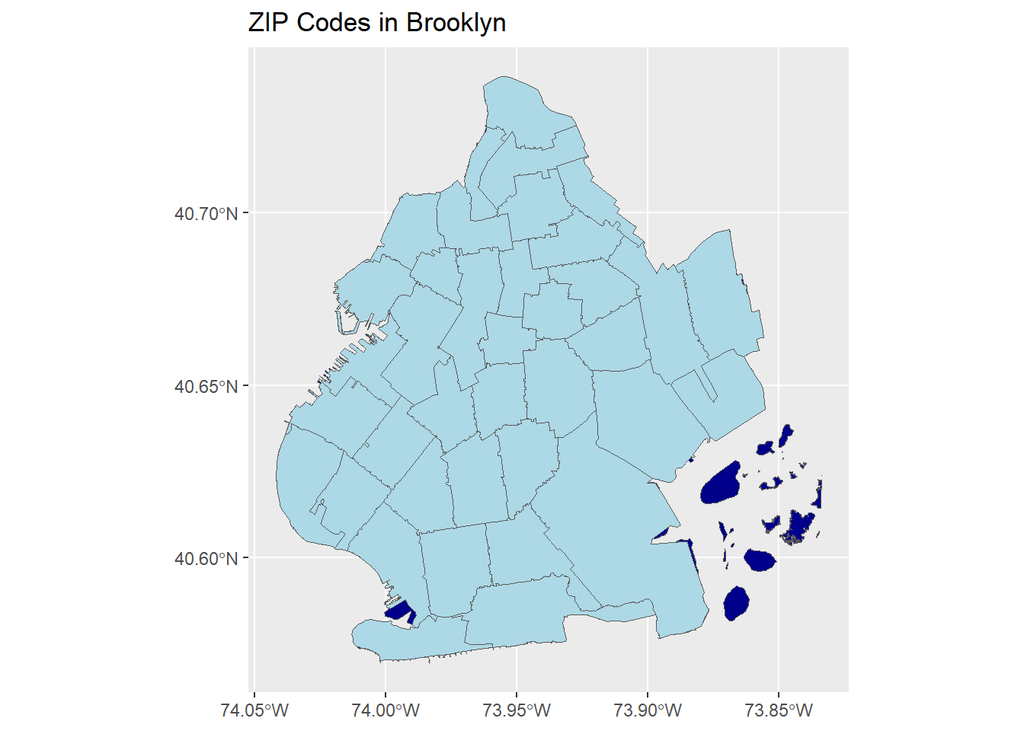

```r
# Create Brooklyn ZIP code plot
ggplot() +
  geom_sf(data = brooklyn, fill = "darkblue") + # Plot the Brooklyn polygon boundary with a dark blue color
  geom_sf(data = brooklyn_zipcodes, fill = "lightblue") + # Plot the Brooklyn ZIP codes with a light blue color
  labs(title = "ZIP Codes in Brooklyn") # Add a title to the plot
```

### 2.2.2. Shooting incidents data

Like the previous step with ZIP codes, we need to convert the shooting incidents data to spatial data, transform the CRS so that we can join them to our prepared ZIP codes, and then determine the number of shooting incidents per ZIP code in 2017.

We will use the `sf::st_as_sf()` function to take the coordinates of each shooting incident location and convert it into a spatial data point. The `coords` option lets us specify which columns in the tabular data contain the longitude and latitude for each point. The `crs` option lets us specify the CRS for the coordinates. In this case, our downloaded data was provided in the WGS84 projection. The number 4326 is the unique identifier for this CRS.

The `sf::st_join` function performs a spatial join operation. All shooting incident points that intersect a ZIP code polygon will be assigned to that ZIP code. Any point that falls outside of our polygons will be excluded from the join.

We can then summarize our data and count the number of points within each polygon.

```r
# Convert shooting incidents to spatial data using provided coordinates
shootings_2017_sf <- st_as_sf(shootings_2017,
                                  coords = c("longitude", "latitude"),
                                  crs = 4326)
# Transform the CRS
# We can use the st_crs() function again to ensure the CRS matches our other data
shootings_2017_sf <- st_transform(shootings_2017_sf,
                                  st_crs(brooklyn_zipcodes))

# Perform a spatial join - shooting incident points to ZIP code polygons
shootings_with_zip <- st_join(shootings_2017_sf, # Point data to join
                                  brooklyn_zipcodes, # Polygon data for joining
                                  join = st_within) # Join type - points must be within our polygons to join

# We will now count the number of shooting incident points in each ZIP code polygon
# Summarize shootings by ZIP code
shootings_by_zip <- shootings_with_zip %>%
  group_by(ZCTA5CE20) %>% # Create a group for each unique ZIP code
  summarize(shootings = n()) # Create a new column called 'shootings' containing a count of points per polygon group

# Merge shooting counts with Brooklyn ZIP code polygons
# Now that we know how many points are in each polygon, we can merge our two dataframes together
brooklyn_zipcodes_shootings <- brooklyn_zipcodes %>%
  left_join(as.data.frame(shootings_by_zip), # The `left_join()` function does not work with 2 sets of spatial data, so we convert shootings to a dataframe
                   by = "ZCTA5CE20") %>%
  # The column relating both dataframes. If the column names do not match, it must be specified in the code (i.e., by = c("var1", "var2"))
  replace(is.na(.), 0) %>% # For any ZIP codes with 0 shooting incidents, replace NA with 0
  rename(zcta = ZCTA5CE20) # Rename ZIP code variable for easier manipulation
```

### 2.2.3. HVI data

We now have our outcome data - the count of shooting incidents per ZIP code. Now, we need to join our exposure (the Heat Vulnerability Index) to these data. Like merging our shooting incidents and ZIP codes above, we will repeat a similar process to merge HVI data to our ZIP codes using the `left_join()` function. Once complete, we will have our final dataset prepared for analysis.

```r
# Join Brooklyn shootings data with HVI data
spatial_data <- brooklyn_zipcodes_shootings %>%
  left_join(hvi, by = "zcta") %>%
  mutate(id = row_number()) # Create an ID variable based on row number

# R-INLA requires the ID variable to be consecutive from 1 to N
# Using row numbers allows us to create an ID variable that will work with R-INLA
```

## 2.3. Data visualization

With our analytic dataset complete, we can now visualize the data.

### 2.3.1. Histograms

Our first step is to create histograms of our exposure (HVI) and outcome (shooting incidents). The ggplot2 package contains the `geom_histogram()` function to do this.

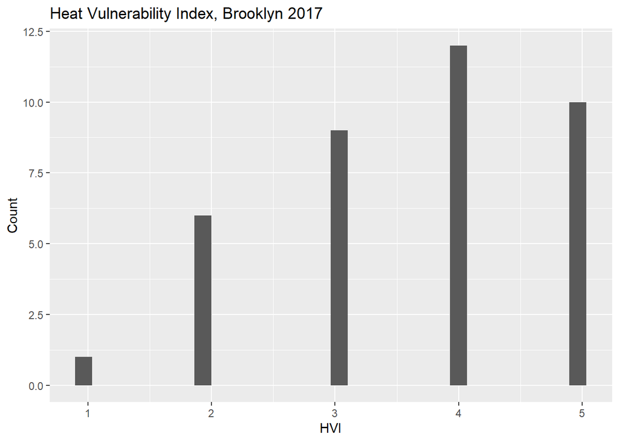

```r
# Histogram for exposure
hist_hvi <- ggplot(spatial_data) + # Dataframe with data of interest
  geom_histogram(aes(x = hvi)) + # Specify the column to plot
  labs(title = "Heat Vulnerability Index, Brooklyn 2017", # Create a title for the plot
       x = "HVI", # Label the x-axis
       y = "Count") # Label the y-axis
# View plot
hist_hvi
```

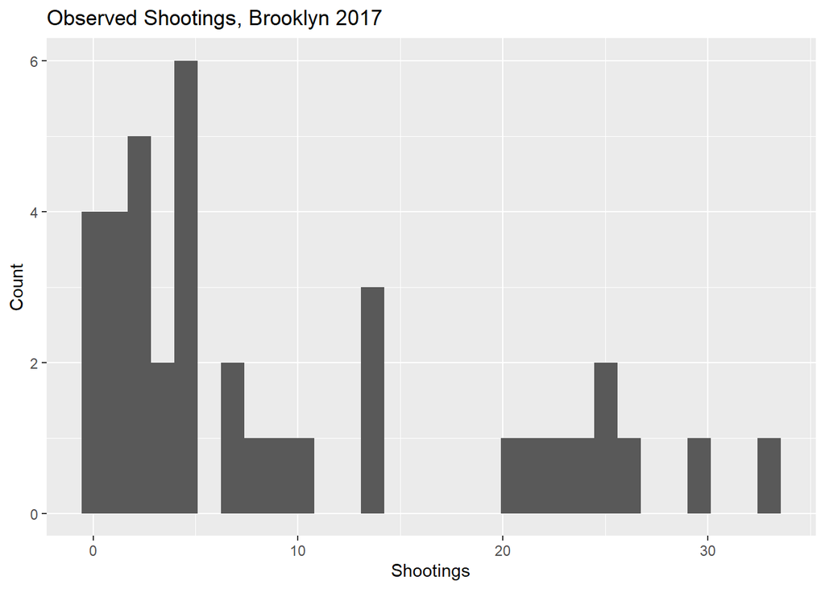

```r
# Histogram for outcome
hist_shoot <- ggplot(spatial_data) +
  geom_histogram(aes(x = shootings)) +
  labs(title = "Observed Shootings, Brooklyn 2017",
       x = "Shootings",
       y = "Count")
# View plot
hist_shoot
```

### 2.3.2. Spatial plots & testing

From the histograms, it looks like we have good variation. However, let’s visualize the data spatially and test for clustering of the outcome.

#### … Spatial visualization

Before testing for clustering in our data, let’s plot the number of shootings per ZIP code to visualize the data.

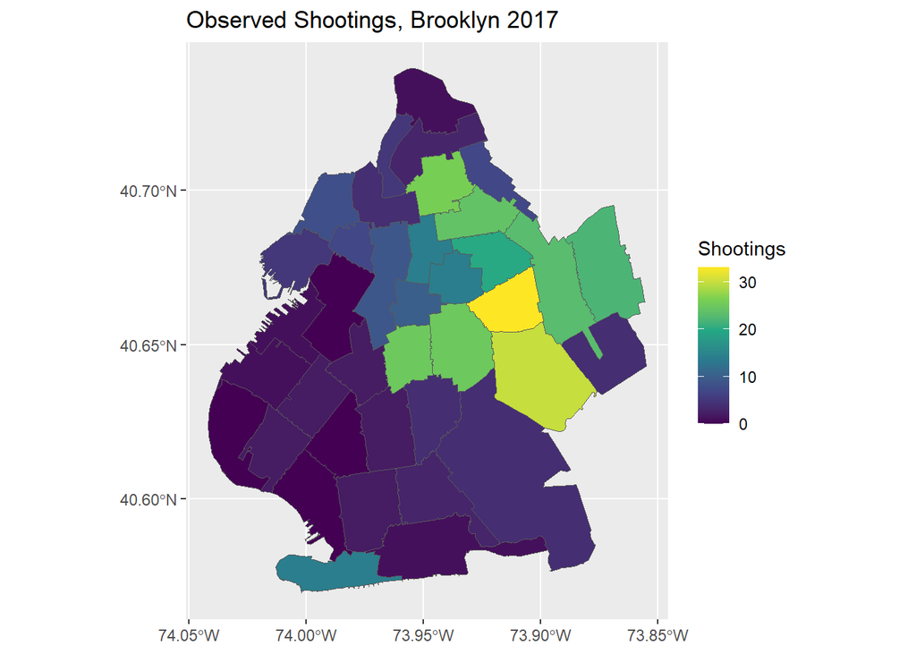

```r
# Create plot
plot_shoot <- ggplot(spatial_data) +
  geom_sf(aes(fill = shootings)) + # Create choropleth map of shooting incidents
  scale_fill_viridis_c() + # Improve plot readability
  labs(title = "Observed Shootings, Brooklyn 2017", fill = "Shootings") # Add title and labels

# View plot
plot_shoot
```

#### … Clustering

Now, let’s test for clustering of shooting incidents. Before we conduct a test for clustering, we need to create a spatial weights matrix. We first need to create a list of polygon neighbors - ZIP codes that share one or more boundary points - using the `spdep::poly2nb()` function. Once we have a list of neighboring polygons, we will be able to create a spatial weights matrix. Since near things are more related than distant things, we need to take this into account when performing any type of spatial analysis. The `spdep::nb2listw()` function will calculate spatial weights from our polygon neighbors.

Then, we will conduct a Moran’s I test for global spatial autocorrelation. Moran’s I will output a score between -1 and 1: -1 indicating total dispersion, 0 indicating random, and 1 indicating total clustering. We will use the `spdep::moran.test()` function to calculate the Moran’s I for shooting incidents.

If the global Moran’s I indicates the presence of clustering, we will conduct a local Moran’s I test. The local Moran’s I can help us identify spatial clusters of shooting incidents with either high or low values. The function `spdep::localmoran()` calculates the local Moran’s I. A positive value for the local Moran’s I indicates that a ZIP code polygon has neighboring polygons with similarly high or low attribute values; this indicates that the polygon is part of a cluster. A negative value for the local Moran’s I indicates that a polygon has neighboring polygons with dissimilar values; this indicates that the polygon is an outlier.

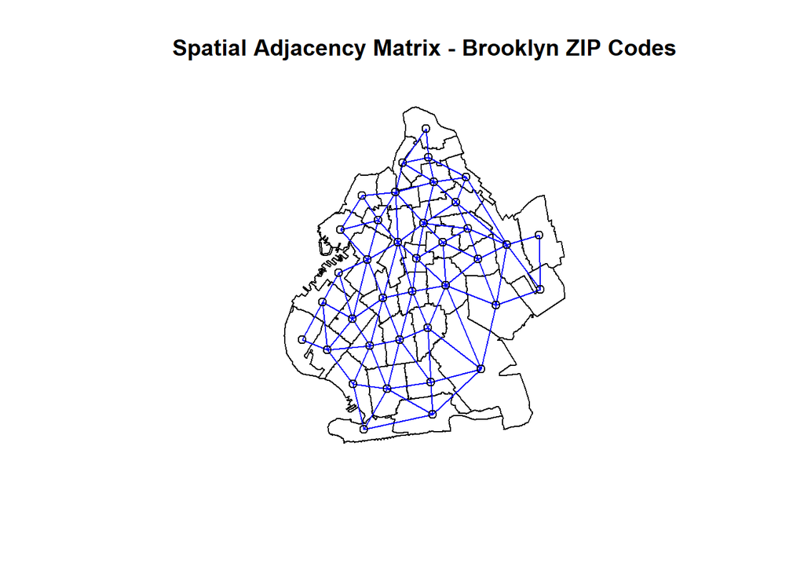

```r
# Create polygon neighbors list and their spatial weights matrix
nb <- poly2nb(spatial_data, row.names=spatial_data$id, queen=TRUE)  # Neighbors list based on ZIP code boundaries
lw <- nb2listw(nb, style = "W")  # Spatial weights list

# Visualize the spatial adjacency matrix
matrix_data <- as_Spatial(spatial_data) # Convert to Spatial* object for plotting
coords <- coordinates(matrix_data) # Get coordinates from ZIP code polygons
# Plot
plot(matrix_data, main = "Spatial Adjacency Matrix - Brooklyn ZIP Codes") # Plot ZIP code polygons
plot(nb, coords, add = TRUE, col = "blue") # Add spatial adjacency matrix
```

```r
# Moran's I test for global spatial autocorrelation
moran_test <- moran.test(spatial_data$shootings, lw) # Conduct test
print(moran_test) # View results
```

```
##
##  Moran I test under randomisation
##
## data:  spatial_data$shootings
## weights: lw
##
## Moran I statistic standard deviate = 4.8218, p-value = 7.114e-07
## alternative hypothesis: greater
## sample estimates:
## Moran I statistic       Expectation          Variance
##        0.46545117       -0.02702703        0.01043179
```

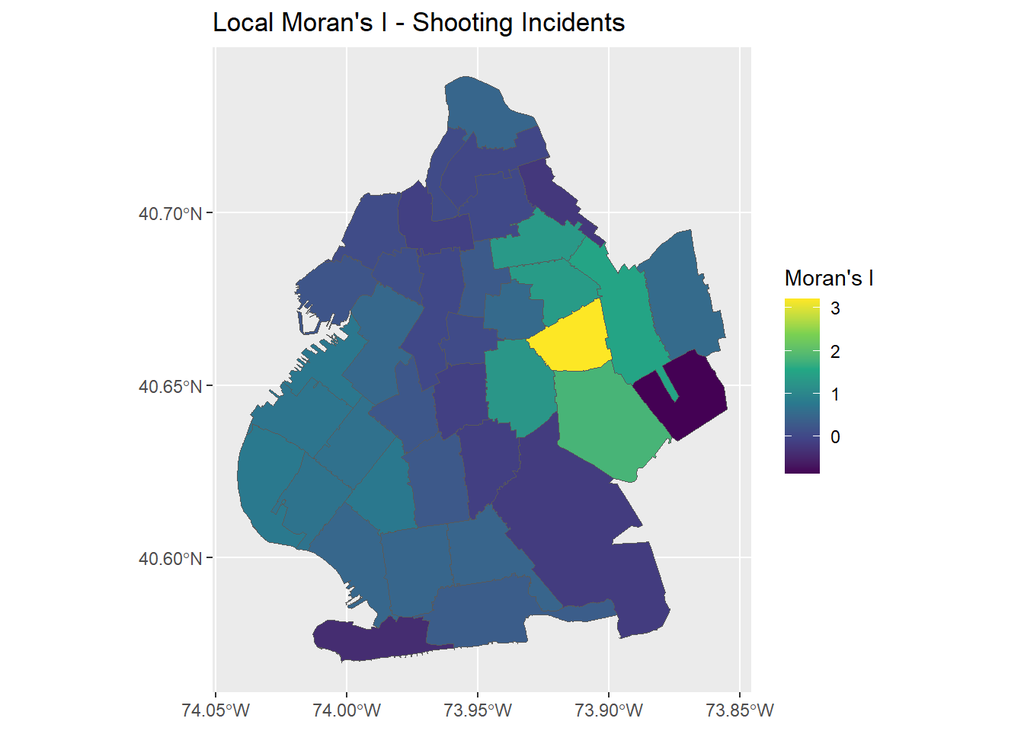

```r
# With a value greater than 0, we see that similar values are clustered together in space
# There are most likely clusters in our data

# Now, we need to determine where the clusters are - use the local Moran's I
# Local Moran's I for clustering
local_moran <- localmoran(spatial_data$shootings, lw) # Conduct test
spatial_data$local_moran <- local_moran[,1]  # Add the results to our spatial data

# Once we have the local Moran's I values we can plot them and visualize our clusters
# Plot the local Moran's I clusters
ggplot(data = spatial_data) +
  geom_sf(aes(fill = local_moran)) +
  scale_fill_viridis_c() +
  labs(title = "Local Moran's I - Shooting Incidents", fill = "Moran's I")
```

```r
# We can see that in the eastern part of Brooklyn, there is indication of a cluster of ZIP codes with similar counts of shooting incidents
```

# 3. Bayesian inference with INLA

With a good idea of what our data look like, we can proceed with our analysis. We also know from previous steps that we need to account for the spatial autocorrelation of our data. We will use the R-INLA package to create a spatial model investigating the association between HVI and shooting incidents.

## 3.1. Create model

Before we run the analytic model, we need to create a spatial adjacency matrix. Similar to our cluster detection above, the INLA model will need to know how near each of our polygons are to each other. We will use the `spdep::nb2mat()` function for this. Once the adjacency matrix is ready, we will create our formula and run the model using the `inla::inla()` function.

```r
# Set up the spatial adjacency matrix
adjacency <- nb2mat(nb, # Use the previously created polygon neighbors list
                    style = "B", # Basic binary coding to create matrix (1 = neighbor; 0 = non-neighbor)
                    zero.policy = TRUE) # Permit the weights list to be formed with zero-length weights vectors

# Model: Shootings as outcome, HVI as predictor, controlling for spatial dependencies
# Specify formula
formula <- shootings ~ hvi + f(id, # Use the consecutive IDs created earlier
                               model = "besag", # Use the Besag model for spatial effects
                               graph = adjacency) # Use the adjacency matrix we just created

# Run the INLA model
result <- inla(formula, # Use the formula we specified above
               data = as.data.frame(spatial_data), # Use data from the `spatial_data` dataframe
               family = "poisson") # Since we have count data, use a Poisson statistical model

# Print the results
inla_result <- summary(result)
inla_result
```

```
## Time used:
##     Pre = 2.79, Running = 4, Post = 0.643, Total = 7.44
## Fixed effects:
##               mean    sd 0.025quant 0.5quant 0.975quant   mode kld
## (Intercept) -0.105 0.577     -1.249   -0.103      1.024 -0.103   0
## hvi          0.474 0.153      0.171    0.474      0.772  0.474   0
##
## Random effects:
##   Name     Model
##     id Besags ICAR model
##
## Model hyperparameters:
##                   mean   sd 0.025quant 0.5quant 0.975quant  mode
## Precision for id 0.555 0.20      0.261    0.523       1.03 0.467
##
## Marginal log-Likelihood:  -153.14
##  is computed
## Posterior summaries for the linear predictor and the fitted values are computed
## (Posterior marginals needs also 'control.compute=list(return.marginals.predictor=TRUE)')
```

## 3.2. Get IRR & credible interval

For easier interpretation, we can get the Incidence Rate Ratio (IRR) from our model along with the credible interval.

```r
# Get the IRR and credible interval
hvi_irr <- round(exp(inla_result$fixed[2, "mean"]),2) # IRR
hvi_quantiles <- inla_result$fixed[2, c("0.025quant", "0.975quant")]
hvi_ci_lower <- round(exp(hvi_quantiles[1]),2)  # Lower bound
hvi_ci_upper <- round(exp(hvi_quantiles[2]),2)  # Upper bound

# Print the IRR and credible interval
# Create a dataframe to hold our calculated values from above
irr_df_inla <- data.frame(
  Variable = "HVI",
  IRR = hvi_irr,
  CrI_Lower = hvi_ci_lower,
  CrI_Upper = hvi_ci_upper
)

# Print results
rownames(irr_df_inla) <- NULL
print(irr_df_inla)
```

```
##   Variable  IRR CrI_Lower CrI_Upper
## 1      HVI 1.61      1.19      2.16
```

## 3.3. Visualize results

We can now visualize the results that we just calculated.

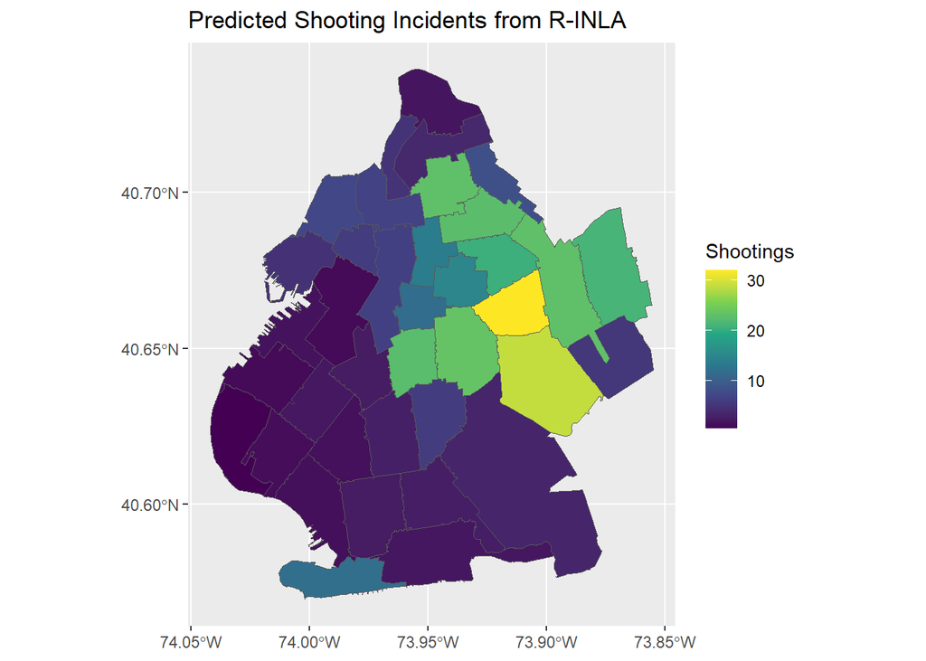

```r
# Create plot of INLA results
# Create a new column in a spatial data that takes on the predicted number of incidents from our INLA model
spatial_data$pred_shootings <- result$summary.fitted.values[, "mean"]

# Plot the results
inla_plot <- ggplot(spatial_data) +
  geom_sf(aes(fill = pred_shootings)) +
  scale_fill_viridis_c() +
  labs(title = "Predicted Shooting Incidents from R-INLA", fill = "Shootings")

# View plot
inla_plot
```

## 3.4. Residuals

To check the fit of our data, we can calculate and visualize the residuals. These will help us assess the quality of the model we created by measuring the difference between observed and predicted values for shooting incidents. Then, we can test for spatial autocorrelation in our residuals. This will help to identify model misspecifications and improve the model’s predictive accuracy. We will use the Moran’s I test again to assess any spatial autocorrelation in the residuals.

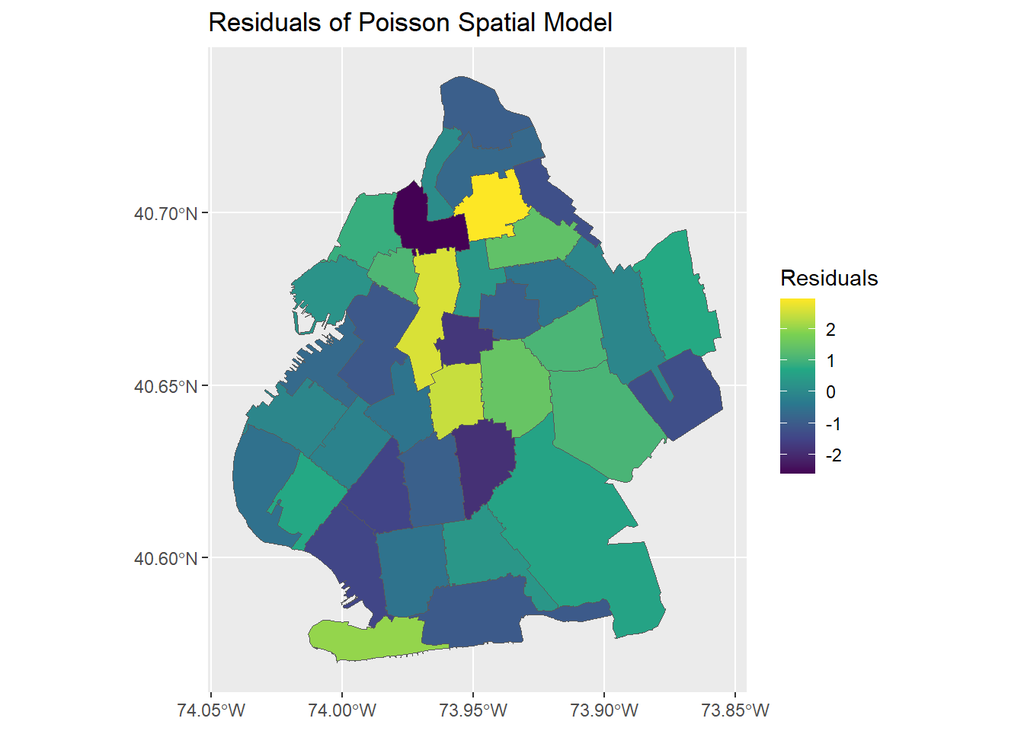

```r
# Calculate residuals
spatial_data$residuals <- spatial_data$shootings - spatial_data$pred_shootings # Subtract predicted values from observed

# Plot residuals
ggplot(spatial_data) +
  geom_sf(aes(fill = residuals)) +
  scale_fill_viridis_c() +
  labs(title = "Residuals of Poisson Spatial Model", fill = "Residuals")
```

```r
# Test for spatial autocorrelation
residual_moran <- moran.test(spatial_data$residuals, lw)
print(residual_moran)
```

```
##
##  Moran I test under randomisation
##
## data:  spatial_data$residuals
## weights: lw
##
## Moran I statistic standard deviate = -1.9067, p-value = 0.9717
## alternative hypothesis: greater
## sample estimates:
## Moran I statistic       Expectation          Variance
##       -0.22151090       -0.02702703        0.01040398
```

# 4. Compare with non-spatial model

Finally, let’s compare our results with a non-spatial model. In this case, we will run the same analysis using a Poisson regression without accounting for spatial autocorrelation.

```r
# Create Poisson model
model <- glm(shootings ~ hvi,
             family="poisson",
             data=spatial_data)

# View results
summary(model)
```

```
##
## Call:
## glm(formula = shootings ~ hvi, family = "poisson", data = spatial_data)
##
## Coefficients:
##             Estimate Std. Error z value Pr(>|z|)
## (Intercept)  -0.4774     0.2706  -1.764   0.0777 .
## hvi           0.6796     0.0616  11.033   <2e-16 ***
## ---
## Signif. codes:  0 '***' 0.001 '**' 0.01 '*' 0.05 '.' 0.1 ' ' 1
##
## (Dispersion parameter for poisson family taken to be 1)
##
##     Null deviance: 377.93  on 37  degrees of freedom
## Residual deviance: 227.74  on 36  degrees of freedom
## AIC: 357.64
##
## Number of Fisher Scoring iterations: 5
```

```r
# Get the IRR and confidence interval
# Calculate IRR & CI
hvi_irr_nonsp <- round(exp(coef(model)["hvi"]),2) # IRR
hvi_conf_int <- round(exp(confint(model)["hvi", ]),2)  # Lower bound
# Create dataframe to store calculations
irr_df <- data.frame(
  Variable = "HVI",
  IRR = hvi_irr_nonsp,
  CI_Lower = hvi_conf_int[1],
  CI_Upper = hvi_conf_int[2]
)

# View results
rownames(irr_df) <- NULL
print(irr_df)
```

```
##   Variable  IRR CI_Lower CI_Upper
## 1      HVI 1.97     1.75     2.23
```

```r
# Compare results
# Print INLA results again
print(irr_df_inla)
```

```
##   Variable  IRR CrI_Lower CrI_Upper
## 1      HVI 1.61      1.19      2.16
```

```r
# We can see that accounting for spatial autocorrelation attenuates our results. For this analysis, a non-spatial model overestimates the effect of HVI on shooting incidents.
```

# 5. Additional resources

In case you would like to learn more about geocomputation or the R-INLA package, here are some additional resources:

- [Geocomputation with R (free online book)](https://r.geocompx.org/)
- [R-INLA (documentation and resources for the R-INLA package)](https://www.r-inla.org/)
- [Bayesian inference with INLA (free online book)](https://becarioprecario.bitbucket.io/inla-gitbook/)